# COD Reproducibility Report

#### Article ID: sDcDq

#### Pilot: Gustav Nilsonne

#### Co-pilot: Tom Hardwicke

#### Start date: 07/13/2017

#### End date: TBD

#### Methods summary:

Children were told two stories, with accompanying pictures shown. In each story, an agent saw two toys on a bookshelf. One toy was larger and more colorful (more attractive, in the researchers’ estimation). Children were randomly assigned to an action and a non-action condition. in the action condition, the agent took the less attractive toy from the shelf, while in the no-action condition the agent did not take a toy from the shelf. Children were then shown the two toys on a blank screen and were asked to indicate which one the agent likes more.

#### Target outcomes:

> 2.2. Results and discussion If children infer preference from a single action, they should be more likely to indicate the worse toy when the agent takes this toy compared to when the agent does not take a toy. To examine this, children were scored 1 each time they indicated the worse toy, and 0 each time they indicated the better toy (maximum score = 2). Children’s mean scores are shown in Fig. 2.

> A 2 (condition: action, no-action) × 2 (age: 3, 4) ANOVA revealed a main effect of condition, F(1, 76) = 47.88, p < 0.001, ηp2 = 0.39, an age by condition interaction, F(1, 76) = 5.32, p = 0.024, ηp2 = 0.07, and no effect of age, F(1, 76) = 0.98, p = 0.326. The main effect of condition resulted because children were more likely to indicate the worse toy when the agent took this toy than when the agent did not take a toy from the shelf. Follow-up analyses indicated that the difference between the conditions emerged in both age groups: 3-year-olds, t(38) = 2.82, p = 0.008, d = 0.91; 4-year-olds, t(38) = 8.05, p < 0.001, d = 2.61. These analyses also revealed that the interaction between age and condition resulted from children at both ages indicating the worse toy at similar rates in the no-action condition, t(38) = 1.08, p = 0.288, but 4-year-olds indicating it more than 3-year-olds in the action condition, t(38) = −2.08, p = 0.044, d = 0.67.

## Step 1: Load packages

```r
library(knitr) # for kable table formating
library(CODreports) # custom report functions
library(readxl) # import excel files
library(plotrix) # to get single command for standard error
library(ez) # To perform ezANOVA
library(compute.es) # To get effect sizes for t-tests
```

## Step 2: Load data

```r
data <- read_xlsx("~/GitHub/set_sDcDq/data/data.xlsx") # This reads sheet 1, which is the right one for experiment 1
```

## Step 3: Tidy data

```r
data$id <- 1:80 # Specify a participant id for the purpose of ezANOVA
```

## Step 4: Run analysis

### Descriptive statistics

> 2.2. Results and discussion If children infer preference from a single action, they should be more likely to indicate the worse toy when the agent takes this toy compared to when the agent does not take a toy. To examine this, children were scored 1 each time they indicated the worse toy, and 0 each time they indicated the better toy (maximum score = 2). Children’s mean scores are shown in Fig. 2.

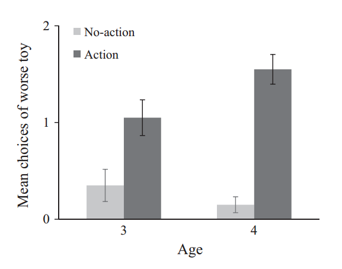

Figure 2 from the paper.

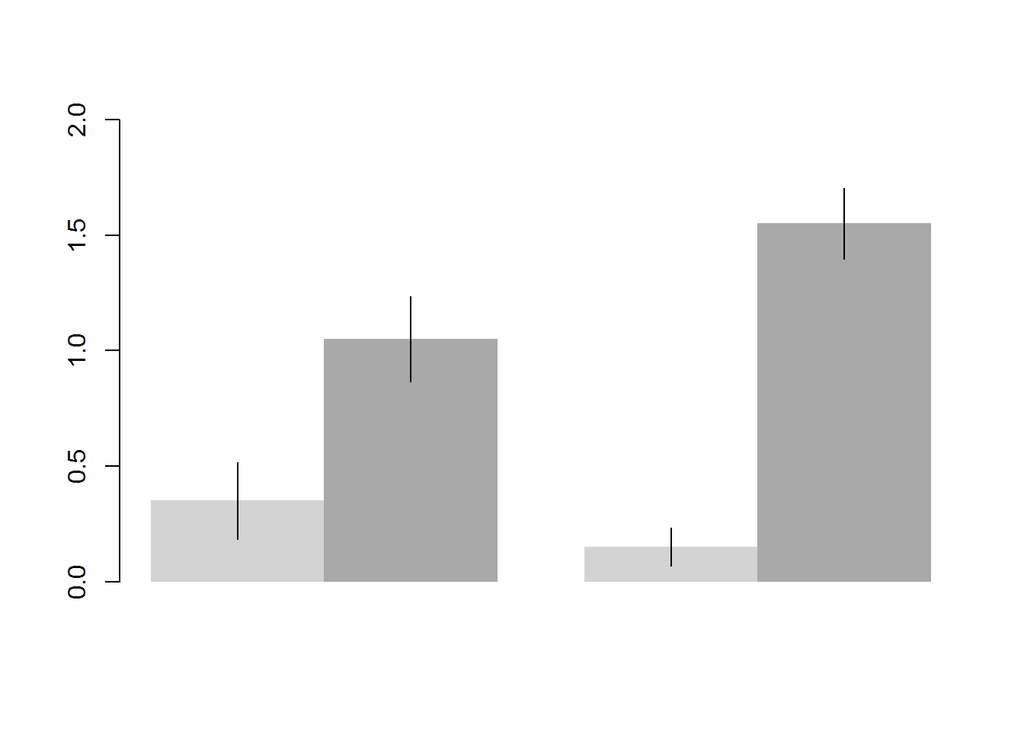

```r
# Get means
agg <- aggregate(score ~ age + condition, data, FUN = "mean")
# Get standard errors
agg2 <- aggregate(score ~ age + condition, data, FUN = "std.error")

# Make barplot
barplot(height = agg$score[c(3, 1, 4, 2)], space = c(0.5, 0, 0.5, 0), col = c("lightgray", "darkgray"), border = NA, ylim = c(0, 2))
# Add error bars
segments(x0 = c(1, 2, 3.5, 4.5), x1 = c(1, 2, 3.5, 4.5), y0 = agg$score[c(3, 1, 4, 2)] - agg2$score[c(3, 1, 4, 2)], y1 = agg$score[c(3, 1, 4, 2)] + agg2$score[c(3, 1, 4, 2)])
```

By inspection of these plots I determine that the values MATCH (all four means and all four standard errors).